# Assignment_Part I

Indira Aryal

10/29/2020

Part I : The language

Chapter 2

Exercise 2.1

```r
a <- 2.3
round((6*a+42)/(3^(4.2-3.62)),5)==29.50556
```

```
## [1] TRUE
```

```r
#i)
```

c)Using R, how would you calculate the square root of half of the

average of the numbers 25.2, 15, 16.44, 15.3, and 18.6?

```r
a<- c(25.2,15,16.44,15.3,18.6)
result <- sqrt(mean(a)/2)
result
```

```
## [1] 3.008987
```

```r
rm(a,result)
```

4. Find $log_e 0.3$

```r
log(0.3)
```

```
## [1] -1.203973
```

e)Compute the exponential transform of your answer to (d).

```r
exp(log(0.3))
```

```
## [1] 0.3
```

f)Identify R’s representation of -0.00000000423546322 when

printing this number to the console.

```r
-0.00000000423546322
```

```
## [1] -4.235463e-09
```

Exercise 2.2

1. Create an object that scores the value 3^2 * 4 ^ (1/8)

```r
b <- 3^2 * 4^(1/8)
b
```

```
## [1] 10.70286
```

b)Overwrite your object in (a) by itself divided by 2.33. Print the

result to the console.

```r
b/2.33
```

```
## [1] 4.593504
```

c)Create a new object with the value -8.2 * 10^(-13).

```r
c <- -8.2 * 10^(-13)
c
```

```
## [1] -8.2e-13
```

d)Print directly to the console the result of multiplying (b) by (c).

```r
b*c
```

```
## [1] -8.776349e-12
```

Exercise 2.3

a)Create and store a sequence of values from 5 to -11 that progresses

in steps of 0.3.

```r
s <- seq(5,-11,by=-0.3)
s
```

```
##  [1]   5.0   4.7   4.4   4.1   3.8   3.5   3.2   2.9   2.6   2.3   2.0   1.7
## [13]   1.4   1.1   0.8   0.5   0.2  -0.1  -0.4  -0.7  -1.0  -1.3  -1.6  -1.9
## [25]  -2.2  -2.5  -2.8  -3.1  -3.4  -3.7  -4.0  -4.3  -4.6  -4.9  -5.2  -5.5
## [37]  -5.8  -6.1  -6.4  -6.7  -7.0  -7.3  -7.6  -7.9  -8.2  -8.5  -8.8  -9.1
## [49]  -9.4  -9.7 -10.0 -10.3 -10.6 -10.9
```

b)Overwrite the object from (a) using the same sequence with the

order reversed.

```r
seq(-11,5,by=0.3)
```

```
##  [1] -11.0 -10.7 -10.4 -10.1  -9.8  -9.5  -9.2  -8.9  -8.6  -8.3  -8.0  -7.7
## [13]  -7.4  -7.1  -6.8  -6.5  -6.2  -5.9  -5.6  -5.3  -5.0  -4.7  -4.4  -4.1
## [25]  -3.8  -3.5  -3.2  -2.9  -2.6  -2.3  -2.0  -1.7  -1.4  -1.1  -0.8  -0.5
## [37]  -0.2   0.1   0.4   0.7   1.0   1.3   1.6   1.9   2.2   2.5   2.8   3.1
## [49]   3.4   3.7   4.0   4.3   4.6   4.9
```

c)Repeat the vector c(-1,3,-5,7,-9) twice, with each element

repeated 10 times, and store the result. Display the result sorted

from largest to smallest.

```r
bar <- rep(x=c(-1,3,-5,7,-9),times=2,each=10)
sort(x=bar,decreasing=TRUE)
```

```
##   [1]  7  7  7  7  7  7  7  7  7  7  7  7  7  7  7  7  7  7  7  7  3  3  3  3  3
##  [26]  3  3  3  3  3  3  3  3  3  3  3  3  3  3  3 -1 -1 -1 -1 -1 -1 -1 -1 -1 -1
##  [51] -1 -1 -1 -1 -1 -1 -1 -1 -1 -1 -5 -5 -5 -5 -5 -5 -5 -5 -5 -5 -5 -5 -5 -5 -5
##  [76] -5 -5 -5 -5 -5 -9 -9 -9 -9 -9 -9 -9 -9 -9 -9 -9 -9 -9 -9 -9 -9 -9 -9 -9 -9
```

4. Create and store a vector that contains, in any configuration, the

following:

i. A sequence of integers from 6 to 12 (inclusive)

ii. A threefold repetition of the value 5.3

iii. The number -3

iv. A sequence of nine values starting at 102 and ending at the

number that is the total length of the vector created in (c)

```r
baz <- c(6:12,rep(5.3,times=3),-3,seq(from=102,to=length(bar),length.out=9))
baz
```

```
##  [1]   6.00   7.00   8.00   9.00  10.00  11.00  12.00   5.30   5.30   5.30
## [11]  -3.00 102.00 101.75 101.50 101.25 101.00 100.75 100.50 100.25 100.00
```

5. Confirm that the length of the vector created in (d) is 20.

```r
length(baz)
```

```
## [1] 20
```

Exercise 2.4

a. Create and store a vector that contains the following, in this

order:

– A sequence of length 5 from 3 to 6 (inclusive)

– A twofold repetition of the vector c(2,-5.1,-33)

– The value 7/42 + 2

b. Extract the first and last elements of your vector from (a), storing

them as a new object.

c. Store as a third object the values returned by omitting the first

and last values of your vector from (a).

d. Use only (b) and (c) to reconstruct (a).

e. Overwrite (a) with the same values sorted from smallest to

largest.

f. Use the colon operator as an index vector to reverse the order

of (e), and confirm this is identical to using sort on (e) with

decreasing=TRUE.

g. Create a vector from (c) that repeats the third element of (c)

three times, the sixth element four times, and the last element

once.

h. Create a new vector as a copy of (e) by assigning (e) as is to a

newly named object. Using this new copy of (e), overwrite the

first, the fifth to the seventh (inclusive), and the last element with

the values 99 to 95 (inclusive), respectively.

```r
#(a)
foo <- c(seq(from=3,to=6,length.out=5),rep(c(2,-5.1,-33),times=2),7/42+2)
foo
```

```
##  [1]   3.000000   3.750000   4.500000   5.250000   6.000000   2.000000
##  [7]  -5.100000 -33.000000   2.000000  -5.100000 -33.000000   2.166667
```

```r
#(b)
bar <- foo[c(1,length(x=foo))]
bar
```

```
## [1] 3.000000 2.166667
```

```r
#(c)
baz <- foo[-c(1,length(x=foo))]
baz
```

```
##  [1]   3.75   4.50   5.25   6.00   2.00  -5.10 -33.00   2.00  -5.10 -33.00
```

```r
#(d)
c(bar[1],baz,bar[2])
```

```
##  [1]   3.000000   3.750000   4.500000   5.250000   6.000000   2.000000
##  [7]  -5.100000 -33.000000   2.000000  -5.100000 -33.000000   2.166667
```

```r
#(e)
foo <- sort(x=foo,decreasing=FALSE)
foo
```

```
##  [1] -33.000000 -33.000000  -5.100000  -5.100000   2.000000   2.000000
##  [7]   2.166667   3.000000   3.750000   4.500000   5.250000   6.000000
```

```r
#(f)
foo[length(x=foo):1]
```

```
##  [1]   6.000000   5.250000   4.500000   3.750000   3.000000   2.166667
##  [7]   2.000000   2.000000  -5.100000  -5.100000 -33.000000 -33.000000
```

```r
sort(x=foo,decreasing=TRUE)
```

```
##  [1]   6.000000   5.250000   4.500000   3.750000   3.000000   2.166667
##  [7]   2.000000   2.000000  -5.100000  -5.100000 -33.000000 -33.000000
```

```r
#(g)
baz[c(rep(x=3,times=3),rep(x=6,times=4),length(x=baz))]
```

```
## [1]   5.25   5.25   5.25  -5.10  -5.10  -5.10  -5.10 -33.00
```

```r
#(h)
qux <- foo
qux[c(1,5:7,12)] <- 99:95
qux
```

```
##  [1]  99.00 -33.00  -5.10  -5.10  98.00  97.00  96.00   3.00   3.75   4.50
## [11]   5.25  95.00
```

Exercise 2.5

a. Convert the vector c(2,0.5,1,2,0.5,1,2,0.5,1) to a vector of only

1s, using a vector of length 3.

b. The conversion from a temperature measurement in degrees

Fahrenheit F to Celsius C is performed using the following

equation:

C =5/9 * ( F - 32)

Use vector-oriented behavior in R to convert the temperatures

45, 77, 20, 19, 101, 120, and 212 in degrees Fahrenheit to

degrees Celsius.

c. Use the vector c(2,4,6) and the vector c(1,2) in conjunction with

rep and * to produce the vector c(2,4,6,4,8,12).

d. Overwrite the middle four elements of the resulting vector from

3. with the two recycled values -0.1 and -100, in that order.

```r
#(a)
c(2,0.5,1,2,0.5,1,2,0.5,1)/c(2,0.5,1)
```

```
## [1] 1 1 1 1 1 1 1 1 1
```

```r
#(b)
faren <- c(45,77,20,19,101,120,212)
cel <- 5/9*(faren-32)
cel
```

```
## [1]   7.222222  25.000000  -6.666667  -7.222222  38.333333  48.888889 100.000000
```

```r
#(c)
foo <- rep(x=c(2,4,6),times=2)*rep(x=c(1,2),each=3)
foo
```

```
## [1]  2  4  6  4  8 12
```

```r
#(d)
foo[2:5] <- c(-0.1,-100)
foo
```

```
## [1]    2.0   -0.1 -100.0   -0.1 -100.0   12.0
```

Exercise 3.1

a. Construct and store a 4 * 2 matrix that’s filled row-wise with the

values 4.3, 3.1, 8.2, 8.2, 3.2, 0.9, 1.6, and 6.5, in that order.

b. Confirm the dimensions of the matrix from (a) are 3 * 2 if you

remove any one row.

c. Overwrite the second column of the matrix from (a) with that

same column sorted from smallest to largest.

d. What does R return if you delete the fourth row and the first column

from (c)? Use matrix to ensure the result is a single-column

matrix, rather than a vector.

e. Store the bottom four elements of (c) as a new 2  2 matrix.

f. Overwrite, in this order, the elements of (c) at positions (4;2),

(1;2), (4;1), and (1;1) with -1/2 of the two values on the diagonal

of (e).

```r
#(a)
mymat <- matrix(data=c(4.3,3.1,8.2,8.2,3.2,0.9,1.6,6.5),nrow=4,ncol=2,byrow=TRUE)
mymat
```

```
##      [,1] [,2]
## [1,]  4.3  3.1
## [2,]  8.2  8.2
## [3,]  3.2  0.9
## [4,]  1.6  6.5
```

```r
#(b)
dim(mymat[-2,])
```

```
## [1] 3 2
```

```r
#(c)
mymat[,2] <- sort(x=mymat[,2])
mymat
```

```
##      [,1] [,2]
## [1,]  4.3  0.9
## [2,]  8.2  3.1
## [3,]  3.2  6.5
## [4,]  1.6  8.2
```

```r
#(d)
mymat[-4,-1]
```

```
## [1] 0.9 3.1 6.5
```

```r
matrix(data=mymat[-4,-1])
```

```
##      [,1]
## [1,]  0.9
## [2,]  3.1
## [3,]  6.5
```

```r
#(e)
mymat2 <- mymat[3:4,]
mymat2
```

```
##      [,1] [,2]
## [1,]  3.2  6.5
## [2,]  1.6  8.2
```

```r
#(f)
mymat[c(4,1),2:1] <- -0.5*diag(mymat2)
```

Exercise 3.2

```r
#(a)
2/7*(cbind(c(1,2,7),c(2,4,6))-cbind(c(10,30,50),c(20,40,60)))
```

```
##            [,1]       [,2]
## [1,]  -2.571429  -5.142857
## [2,]  -8.000000 -10.285714
## [3,] -12.285714 -15.428571
```

```r
#(b)
A <- matrix(data=c(1,2,7))
B <- matrix(data=c(3,4,8))
##(i) Not possible
##(ii)
t(A)%*%B
```

```
##      [,1]
## [1,]   67
```

```r
##(iii)
t(B)%*%(A%*%t(A))
```

```
##      [,1] [,2] [,3]
## [1,]   67  134  469
```

```r
##(iv) Not possible
##(v)
solve(B%*%t(B)+A%*%t(A)-100*diag(3))
```

```
##              [,1]         [,2]        [,3]
## [1,] -0.007923676  0.003123274 0.007843334
## [2,]  0.003123274 -0.005350239 0.011483806
## [3,]  0.007843334  0.011483806 0.017584735
```

```r
#(c)
A <- rbind(c(2,0,0,0),c(0,3,0,0),c(0,0,5,0),c(0,0,0,-1))
solve(A)%*%A-diag(4)
```

```
##      [,1] [,2] [,3] [,4]
## [1,]    0    0    0    0
## [2,]    0    0    0    0
## [3,]    0    0    0    0
## [4,]    0    0    0    0
```

Exercise 3.3

a. Create and store a three-dimensional array with six layers of a

4  2 matrix, filled with a decreasing sequence of values between

4.8 and 0.1 of the appropriate length.

b. Extract and store as a new object the fourth- and first-row elements,

in that order, of the second column only of all layers

of (a).

c. Use a fourfold repetition of the second row of the matrix formed

in (b) to fill a new array of dimensions 2 * 2 * 2 * 3.

d. Create a new array comprised of the results of deleting the sixth

layer of (a).

e. Overwrite the second and fourth row elements of the second

column of layers 1, 3, and 5 of (d) with -99.

```r
#(a)
AR <- array(data=seq(from=4.8,to=0.1,length.out=48),dim=c(4,2,6))
AR
```

```
## , , 1
##
##      [,1] [,2]
## [1,]  4.8  4.4
## [2,]  4.7  4.3
## [3,]  4.6  4.2
## [4,]  4.5  4.1
##
## , , 2
##
##      [,1] [,2]
## [1,]  4.0  3.6
## [2,]  3.9  3.5
## [3,]  3.8  3.4
## [4,]  3.7  3.3
##
## , , 3
##
##      [,1] [,2]
## [1,]  3.2  2.8
## [2,]  3.1  2.7
## [3,]  3.0  2.6
## [4,]  2.9  2.5
##
## , , 4
##
##      [,1] [,2]
## [1,]  2.4  2.0
## [2,]  2.3  1.9
## [3,]  2.2  1.8
## [4,]  2.1  1.7
##
## , , 5
##
##      [,1] [,2]
## [1,]  1.6  1.2
## [2,]  1.5  1.1
## [3,]  1.4  1.0
## [4,]  1.3  0.9
##
## , , 6
##
##      [,1] [,2]
## [1,]  0.8  0.4
## [2,]  0.7  0.3
## [3,]  0.6  0.2
## [4,]  0.5  0.1
```

```r
#(b)
BR <- AR[c(4,1),2,]
BR
```

```
##      [,1] [,2] [,3] [,4] [,5] [,6]
## [1,]  4.1  3.3  2.5  1.7  0.9  0.1
## [2,]  4.4  3.6  2.8  2.0  1.2  0.4
```

```r
#(c)
CR <- array(data=rep(x=BR[2,],times=4),dim=c(2,2,2,3))
CR
```

```
## , , 1, 1
##
##      [,1] [,2]
## [1,]  4.4  2.8
## [2,]  3.6  2.0
##
## , , 2, 1
##
##      [,1] [,2]
## [1,]  1.2  4.4
## [2,]  0.4  3.6
##
## , , 1, 2
##
##      [,1] [,2]
## [1,]  2.8  1.2
## [2,]  2.0  0.4
##
## , , 2, 2
##
##      [,1] [,2]
## [1,]  4.4  2.8
## [2,]  3.6  2.0
##
## , , 1, 3
##
##      [,1] [,2]
## [1,]  1.2  4.4
## [2,]  0.4  3.6
##
## , , 2, 3
##
##      [,1] [,2]
## [1,]  2.8  1.2
## [2,]  2.0  0.4
```

```r
#(d)
DR <- AR[,,-6]
DR
```

```
## , , 1
##
##      [,1] [,2]
## [1,]  4.8  4.4
## [2,]  4.7  4.3
## [3,]  4.6  4.2
## [4,]  4.5  4.1
##
## , , 2
##
##      [,1] [,2]
## [1,]  4.0  3.6
## [2,]  3.9  3.5
## [3,]  3.8  3.4
## [4,]  3.7  3.3
##
## , , 3
##
##      [,1] [,2]
## [1,]  3.2  2.8
## [2,]  3.1  2.7
## [3,]  3.0  2.6
## [4,]  2.9  2.5
##
## , , 4
##
##      [,1] [,2]
## [1,]  2.4  2.0
## [2,]  2.3  1.9
## [3,]  2.2  1.8
## [4,]  2.1  1.7
##
## , , 5
##
##      [,1] [,2]
## [1,]  1.6  1.2
## [2,]  1.5  1.1
## [3,]  1.4  1.0
## [4,]  1.3  0.9
```

```r
#(e)
DR[c(2,4),2,c(1,3,5)] <- -99
DR
```

```
## , , 1
##
##      [,1]  [,2]
## [1,]  4.8   4.4
## [2,]  4.7 -99.0
## [3,]  4.6   4.2
## [4,]  4.5 -99.0
##
## , , 2
##
##      [,1] [,2]
## [1,]  4.0  3.6
## [2,]  3.9  3.5
## [3,]  3.8  3.4
## [4,]  3.7  3.3
##
## , , 3
##
##      [,1]  [,2]
## [1,]  3.2   2.8
## [2,]  3.1 -99.0
## [3,]  3.0   2.6
## [4,]  2.9 -99.0
##
## , , 4
##
##      [,1] [,2]
## [1,]  2.4  2.0
## [2,]  2.3  1.9
## [3,]  2.2  1.8
## [4,]  2.1  1.7
##
## , , 5
##
##      [,1]  [,2]
## [1,]  1.6   1.2
## [2,]  1.5 -99.0
## [3,]  1.4   1.0
## [4,]  1.3 -99.0
```

Chapter 4

Exercise 4.1

a. Store the following vector of 15 values as an object in your

workspace: c(6,9,7,3,6,7,9,6,3,6,6,7,1,9,1). Identify the following

elements:

i. Those equal to 6

ii. Those greater than or equal to 6

iii. Those less than 6 + 2

iv. Those not equal to 6

b. Create a new vector from the one used in (a) by deleting its

first three elements. With this new vector, fill a 2  2  3 array.

Examine the array for the following entries:

i. Those less than or equal to 6 divided by 2, plus 4

ii. Those less than or equal to 6 divided by 2, plus 4, after

increasing every element in the array by 2

c. Confirm the specific locations of elements equal to 0 in the

10  10 identity matrix I10 (see Section 3.3).

d. Check whether any of the values of the logical arrays created in

2. are TRUE. If they are, check whether they are all TRUE.

e. By extracting the diagonal elements of the logical matrix created

in (c), use any to confirm there are no TRUE entries.

```r
#(a)
foo <- c(6,9,7,3,6,7,9,6,3,6,6,7,1,9,1)
foo
```

```
##  [1] 6 9 7 3 6 7 9 6 3 6 6 7 1 9 1
```

```r
foo==6
```

```
##  [1]  TRUE FALSE FALSE FALSE  TRUE FALSE FALSE  TRUE FALSE  TRUE  TRUE FALSE
## [13] FALSE FALSE FALSE
```

```r
foo>=6
```

```
##  [1]  TRUE  TRUE  TRUE FALSE  TRUE  TRUE  TRUE  TRUE FALSE  TRUE  TRUE  TRUE
## [13] FALSE  TRUE FALSE
```

```r
foo<(6+2)
```

```
##  [1]  TRUE FALSE  TRUE  TRUE  TRUE  TRUE FALSE  TRUE  TRUE  TRUE  TRUE  TRUE
## [13]  TRUE FALSE  TRUE
```

```r
foo!=6
```

```
##  [1] FALSE  TRUE  TRUE  TRUE FALSE  TRUE  TRUE FALSE  TRUE FALSE FALSE  TRUE
## [13]  TRUE  TRUE  TRUE
```

```r
#(b)
bar <- foo[-(1:3)]
bar <- array(data=bar,dim=c(2,2,3))
bar
```

```
## , , 1
##
##      [,1] [,2]
## [1,]    3    7
## [2,]    6    9
##
## , , 2
##
##      [,1] [,2]
## [1,]    6    6
## [2,]    3    6
##
## , , 3
##
##      [,1] [,2]
## [1,]    7    9
## [2,]    1    1
```

```r
bar<=(6/2+4)
```

```
## , , 1
##
##      [,1]  [,2]
## [1,] TRUE  TRUE
## [2,] TRUE FALSE
##
## , , 2
##
##      [,1] [,2]
## [1,] TRUE TRUE
## [2,] TRUE TRUE
##
## , , 3
##
##      [,1]  [,2]
## [1,] TRUE FALSE
## [2,] TRUE  TRUE
```

```r
(bar+2)<=(6/2+4)
```

```
## , , 1
##
##       [,1]  [,2]
## [1,]  TRUE FALSE
## [2,] FALSE FALSE
##
## , , 2
##
##       [,1]  [,2]
## [1,] FALSE FALSE
## [2,]  TRUE FALSE
##
## , , 3
##
##       [,1]  [,2]
## [1,] FALSE FALSE
## [2,]  TRUE  TRUE
```

```r
#(c)
diag(10)==0
```

```
##        [,1]  [,2]  [,3]  [,4]  [,5]  [,6]  [,7]  [,8]  [,9] [,10]
##  [1,] FALSE  TRUE  TRUE  TRUE  TRUE  TRUE  TRUE  TRUE  TRUE  TRUE
##  [2,]  TRUE FALSE  TRUE  TRUE  TRUE  TRUE  TRUE  TRUE  TRUE  TRUE
##  [3,]  TRUE  TRUE FALSE  TRUE  TRUE  TRUE  TRUE  TRUE  TRUE  TRUE
##  [4,]  TRUE  TRUE  TRUE FALSE  TRUE  TRUE  TRUE  TRUE  TRUE  TRUE
##  [5,]  TRUE  TRUE  TRUE  TRUE FALSE  TRUE  TRUE  TRUE  TRUE  TRUE
##  [6,]  TRUE  TRUE  TRUE  TRUE  TRUE FALSE  TRUE  TRUE  TRUE  TRUE
##  [7,]  TRUE  TRUE  TRUE  TRUE  TRUE  TRUE FALSE  TRUE  TRUE  TRUE
##  [8,]  TRUE  TRUE  TRUE  TRUE  TRUE  TRUE  TRUE FALSE  TRUE  TRUE
##  [9,]  TRUE  TRUE  TRUE  TRUE  TRUE  TRUE  TRUE  TRUE FALSE  TRUE
## [10,]  TRUE  TRUE  TRUE  TRUE  TRUE  TRUE  TRUE  TRUE  TRUE FALSE
```

```r
#(d)
any(bar<=(6/2+4))
```

```
## [1] TRUE
```

```r
all(bar<=(6/2+4))
```

```
## [1] FALSE
```

```r
any((bar+2)<=(6/2+4))
```

```
## [1] TRUE
```

```r
all((bar+2)<=(6/2+4))
```

```
## [1] FALSE
```

```r
#(e)
any(diag(diag(10)==0))
```

```
## [1] FALSE
```

Exercise 4.2

a. Store the vector c(7,1,7,10,5,9,10,3,10,8) as foo. Identify the

elements greater than 5 OR equal to 2.

b. Store the vector c(8,8,4,4,5,1,5,6,6,8) as bar. Identify the elements

less than or equal to 6 AND not equal to 4.

c. Identify the elements that satisfy (a) in foo AND satisfy (b) in bar.

d. Store a third vector called baz that is equal to the element-wise

sum of foo and bar. Determine the following:

i. The elements of baz greater than or equal to 14 but not

equal to 15

ii. The elements of the vector obtained via an element-wise

division of baz by foo that are greater than 4 OR less than or

equal to 2

e. Confirm that using the long version in all of the preceding

exercises performs only the first comparison (that is, the results

each match the first entries of the previously obtained vectors).

```r
#(a)
foo <- c(7,1,7,10,5,9,10,3,10,8)
(foo>5)|(foo==2)
```

```
##  [1]  TRUE FALSE  TRUE  TRUE FALSE  TRUE  TRUE FALSE  TRUE  TRUE
```

```r
#(b)
bar <- c(8,8,4,4,5,1,5,6,6,8)
(bar<=6)&(bar!=4)
```

```
##  [1] FALSE FALSE FALSE FALSE  TRUE  TRUE  TRUE  TRUE  TRUE FALSE
```

```r
#(c)
((foo>5)|(foo==2))&((bar<=6)&(bar!=4))
```

```
##  [1] FALSE FALSE FALSE FALSE FALSE  TRUE  TRUE FALSE  TRUE FALSE
```

```r
#(d)
baz <- foo+bar
baz
```

```
##  [1] 15  9 11 14 10 10 15  9 16 16
```

```r
##(i)
(baz>=14)&(baz!=15)
```

```
##  [1] FALSE FALSE FALSE  TRUE FALSE FALSE FALSE FALSE  TRUE  TRUE
```

```r
##(ii)
(baz/foo>4)|(baz/foo<=2)
```

```
##  [1] FALSE  TRUE  TRUE  TRUE  TRUE  TRUE  TRUE FALSE  TRUE  TRUE
```

```r
#(e)
(foo>5)||(foo==2)
```

```
## [1] TRUE
```

```r
(bar<=6)&&(bar!=4)
```

```
## [1] FALSE
```

```r
((foo>5)||(foo==2))&&((bar<=6)&&(bar!=4))
```

```
## [1] FALSE
```

```r
(baz>=14)&&(baz!=15)
```

```
## [1] FALSE
```

```r
(baz/foo>4)||(baz/foo<=2)
```

```
## [1] FALSE
```

Exercise 4.3

a. Store this vector of 10 values: foo <- c(7,5,6,1,2,10,8,3,8,2).

Then, do the following:

i. Extract the elements greater than or equal to 5, storing the

result as bar.

ii. Display the vector containing those elements from foo that

remain after omitting all elements that are greater than or

equal to 5.

b. Use bar from (a)(i) to construct a 2  3 matrix called baz, filled in

a row-wise fashion. Then, do the following:

i. Replace any elements that are equal to 8 with the squared

value of the element in row 1, column 2 of baz itself.

ii. Confirm that all values in baz are now less than or equal to 25

AND greater than 4.

c. Create a 3  2  3 array called qux using the following vector of

18 values: c(10,5,1,4,7,4,3,3,1,3,4,3,1,7,8,3,7,3). Then, do the

following:

i. Identify the dimension-specific index positions of elements

that are either 3 OR 4.

ii. Replace all elements in qux that are less than 3 OR greater

than or equal to 7 with the value 100.

d. Return to foo from (a). Use the vector c(F,T) to extract every

second value from foo. In Section 4.1.4, you saw that in some

situations, you can substitute 0 and 1 for TRUE and FALSE. Can you

perform the same extraction from foo using the vector c(0,1)?

Why or why not? What does R return in this case?

```r
#(a)
foo <- c(7,5,6,1,2,10,8,3,8,2)
##(i)
bar <- foo[foo>=5]
##(ii)
foo[-which(x=foo>=5)]
```

```
## [1] 1 2 3 2
```

```r
#(b)
baz <- matrix(data=bar,nrow=2,ncol=3,byrow=T)
##(i)
baz[baz==8] <- baz[1,2]^2
##(ii)
all(baz<=25&baz>4)
```

```
## [1] TRUE
```

```r
#(c)
qux <- array(data=c(10,5,1,4,7,4,3,3,1,3,4,3,1,7,8,3,7,3),dim=c(3,2,3))
##(i)
which(x=qux==3|qux==4,arr.ind=T)
```

```
##       dim1 dim2 dim3
##  [1,]    1    2    1
##  [2,]    3    2    1
##  [3,]    1    1    2
##  [4,]    2    1    2
##  [5,]    1    2    2
##  [6,]    2    2    2
##  [7,]    3    2    2
##  [8,]    1    2    3
##  [9,]    3    2    3
```

```r
##(ii)
qux[qux<3|qux>=7] <- 100
#(d)
foo[c(F,T)]
```

```
## [1]  5  1 10  3  2
```

```r
foo[c(0,1)]
```

```
## [1] 7
```

Exercise 4.4

a. Re-create exactly the following output:

"The quick brown fox

jumped over

the lazy dogs"

b. Suppose you’ve stored the values num1 <- 4 and num2 <- 0.75.

Write a line of R code that returns the following string:

[1] “The result of multiplying 4 by 0.75 is 3”

Make sure your code produces a string with the correct

multiplication result for any two numbers stored as num1 and num2.

c. On my local machine, the directory for my work on this book is

specified in R as “/Users/tdavies/Documents/RBook/”. Imagine it is

your machine—write a line of code that replaces tdavies in this

string with your first initial and surname.

d. In Section 4.2.4, you stored the following string:

R> bar <- “How much wood could a woodchuck chuck”

i. Store a new string by gluing onto bar the words

“if a woodchuck could chuck wood”.

ii. In the result of (i), replace all instances of wood with metal.

e. Store the string “Two 6-packs for $12.99”. Then do the following:

i. Use a check for equality to confirm that the substring

beginning with character 5 and ending with character 10

is “6-pack”.

ii. Make it a better deal by changing the price to $10.99.

```r
#(a)
cat("\"The quick brown fox\n\tjumped over\n\t\tthe lazy dogs\"")
```

```
## "The quick brown fox
##  jumped over
##      the lazy dogs"
```

```r
#(b)
num1 <- 4
num2 <- 0.75
paste("The result of multiplying",num1,"by",num2,"is",num1*num2)
```

```
## [1] "The result of multiplying 4 by 0.75 is 3"
```

```r
#(c)
sub(pattern="tdavies",replacement="aschwarzenegger",x="/Users/tdavies/Documents/RBook")
```

```
## [1] "/Users/aschwarzenegger/Documents/RBook"
```

```r
#(d)
bar <- "How much wood could a woodchuck chuck"
##(i)
baz <- paste(bar,"if a woodchuck could chuck wood")
##(ii)
gsub(pattern="wood",replacement="metal",x=baz)
```

```
## [1] "How much metal could a metalchuck chuck if a metalchuck could chuck metal"
```

```r
#(e)
foo <- "Two 6-packs for $12.99"
#(i)
substr(x=foo,start=5,stop=10)=="6-pack"
```

```
## [1] TRUE
```

```r
#(ii)
substr(x=foo,start=19,stop=19) <- "0"
foo
```

```
## [1] "Two 6-packs for $10.99"
```

Exercise 4.5

The New Zealand government consists of the political parties

National, Labour, Greens, and M¯aori, with several smaller parties

labeled as Other. Suppose you asked 20 New Zealanders which of

these they identified most with and obtained the following data:

• There were 12 males and 8 females; the individuals numbered 1,

5–7, 12, and 14–16 were females.

• The individuals numbered 1, 4, 12, 15, 16, and 19 identified with

Labour; no one identified with M¯aori; the individuals numbered

6, 9, and 11 identified with Greens; 10 and 20 identified with

Other; and the rest identified with National.

a. Use your knowledge of vectors (for example, subsetting and

overwriting) to create two character vectors: sex with entries

“M” (male) and “F” (female) and party with entries “National”,

“Labour”, “Greens”, “Maori”, and “Other”. Make sure the entries are

placed in the correct positions as outlined earlier.

b. Create two different factor vectors based on sex and party. Does

it make any sense to use ordered=TRUE in either case? How has R

appeared to arrange the levels?

c. Use factor subsetting to do the following:

i. Return the factor vector of chosen parties for only the male

participants.

ii. Return the factor vector of genders for those who chose

National.

d. Another six people joined the survey, with the results

c(“National”,“Maori”,“Maori”,“Labour”,“Greens”,“Labour”) for the

preferred party and c(“M”,“M”,“F”,“F”,“F”,“M”) as their gender.

Combine these results with the original factors from (b).

Suppose you also asked all individuals to state how confident they

were that Labour will win more seats in Parliament than National

in the next election and to attach a subjective percentage to that

confidence. The following 26 results were obtained: 93, 55, 29, 100,

52, 84, 56, 0, 33, 52, 35, 53, 55, 46, 40, 40, 56, 45, 64, 31, 10, 29, 40,

95, 18, 61.

e. Create a factor with levels of confidence as follows: Low for

percentages [0,30]; Moderate for percentages (30,70]; and

High for percentages (70,100].

f. From (e), extract the levels corresponding to those individuals

who originally said they identified with Labour. Do this also for

National. What do you notice?

```r
#(a)
party <- rep("National",20)
party[c(1,4,12,15,16,19)] <- "Labour"
party[c(6,9,11)] <- "Greens"
party[c(10,20)] <- "Other"
party
```

```
##  [1] "Labour"   "National" "National" "Labour"   "National" "Greens"
##  [7] "National" "National" "Greens"   "Other"    "Greens"   "Labour"
## [13] "National" "National" "Labour"   "Labour"   "National" "National"
## [19] "Labour"   "Other"
```

```r
sex <- rep("M",20)
sex[c(1,5:7,12,14:16)] <- "F"
sex
```

```
##  [1] "F" "M" "M" "M" "F" "F" "F" "M" "M" "M" "M" "F" "M" "F" "F" "F" "M" "M" "M"
## [20] "M"
```

```r
#(b)
sex.fac <- factor(x=sex)
sex.fac
```

```
##  [1] F M M M F F F M M M M F M F F F M M M M
## Levels: F M
```

```r
party.fac <- factor(x=party,levels=c("National","Labour","Greens","Maori","Other"))
party.fac # Should not use ordered=TRUE, there is no 'natural' or 'low-to-high' ordering here. Factor levels are arranged in the order specified in the 'levels' argument.
```

```
##  [1] Labour   National National Labour   National Greens   National National
##  [9] Greens   Other    Greens   Labour   National National Labour   Labour
## [17] National National Labour   Other
## Levels: National Labour Greens Maori Other
```

```r
#(c)
##(i)
party.fac[sex.fac=="M"]
```

```
##  [1] National National Labour   National Greens   Other    Greens   National
##  [9] National National Labour   Other
## Levels: National Labour Greens Maori Other
```

```r
##(ii)
sex.fac[party.fac=="National"]
```

```
## [1] M M F F M M F M M
## Levels: F M
```

```r
#(d)
sex.newvals <- factor(x=c("M","M","F","F","F","M"))
sex.fac <- factor(x=levels(sex.fac)[c(sex.fac,sex.newvals)])
sex.fac
```

```
##  [1] F M M M F F F M M M M F M F F F M M M M M M F F F M
## Levels: F M
```

```r
party.newvals <- factor(x=c("National","Maori","Maori","Labour","Greens","Labour"),levels=levels(party.fac))
party.fac <- factor(x=levels(party.fac)[c(party.fac,party.newvals)])
party.fac
```

```
##  [1] Labour   National National Labour   National Greens   National National
##  [9] Greens   Other    Greens   Labour   National National Labour   Labour
## [17] National National Labour   Other    National Maori    Maori    Labour
## [25] Greens   Labour
## Levels: Greens Labour Maori National Other
```

```r
#(e)
conf <- c(93,55,29,100,52,84,56,0,33,52,35,53,55,46,40,40,56,45,64,31,10,29,40,95,18,61)
conf.fac <- cut(x=conf,breaks=c(0,30,70,100),include.lowest=TRUE,labels=c("Low","Moderate","High"))
#(f)
conf.fac[party.fac=="Labour"]
```

```
## [1] High     High     Moderate Moderate Moderate Moderate High     Moderate
## Levels: Low Moderate High
```

```r
conf.fac[party.fac=="National"] # Theres an indication that those who identify as "Labour" have greater confidence than those who identify as "National" when it comes to guessing how well Labour will do in the next election.
```

```
##  [1] Moderate Low      Moderate Moderate Low      Moderate Moderate Moderate
##  [9] Moderate Low
## Levels: Low Moderate High
```

Exercise 5.1

```r
#(a)
foo <- list(seq(from=-4,to=4,length=20),matrix(c(F,T,T,T,F,T,T,F,F),nrow=3,ncol=3),c("don","quixote"),factor(x=c("LOW","MED","LOW","MED","MED","HIGH")))
##(i)
foo[[2]][2:1,2:3]
```

```
##       [,1]  [,2]
## [1,] FALSE FALSE
## [2,]  TRUE  TRUE
```

```r
##(ii)
foo[[3]][1] <- sub(pattern="d",replacement="D",x=foo[[3]][1])
foo[[3]][2] <- sub(pattern="q",replacement="Q",x=foo[[3]][2])
cat("\"Windmills! ATTACK!\"\n\t-\\",foo[[3]][1]," ",foo[[3]][2],"/-",sep="")
```

```
## "Windmills! ATTACK!"
##  -\Don Quixote/-
```

```r
##(iii)
foo[[1]][foo[[1]]>1]
```

```
## [1] 1.052632 1.473684 1.894737 2.315789 2.736842 3.157895 3.578947 4.000000
```

```r
##(iv)
which(x=foo[[4]]=="MED")
```

```
## [1] 2 4 5
```

```r
#(b)
bar <- list(facs=foo[[4]],nums=c(3,2.1,3.3,4,1.5,4.9),oldlist=foo[1:3])
##(i)
bar$facs[bar$nums>=3]
```

```
## [1] LOW  LOW  MED  HIGH
## Levels: HIGH LOW MED
```

```r
##(ii)
bar$flags <- rep(x=bar$oldlist[[2]][,3],times=2)
##(iii)
bar$nums[!bar$flags]
```

```
## [1] 2.1 3.3 1.5 4.9
```

```r
##(iv)
bar$oldlist[[3]] <- "Don Quixote"
```

Exercise 5.2

```r
#(a)
dframe <- data.frame(person=c("Stan","Francine","Steve","Roger","Hayley","Klaus"),sex=factor(x=c("M","F","M","M","F","M")),funny=factor(x=c("High","Med","Low","High","Med","Med"),levels=c("Low","Med","High")),stringsAsFactors=T)
dframe
```

```
##     person sex funny
## 1     Stan   M  High
## 2 Francine   F   Med
## 3    Steve   M   Low
## 4    Roger   M  High
## 5   Hayley   F   Med
## 6    Klaus   M   Med
```

```r
#(b)
dframe$age <- c(41,41,15,1600,21,60)
dframe
```

```
##     person sex funny  age
## 1     Stan   M  High   41
## 2 Francine   F   Med   41
## 3    Steve   M   Low   15
## 4    Roger   M  High 1600
## 5   Hayley   F   Med   21
## 6    Klaus   M   Med   60
```

```r
#(c)
dframe <- dframe[,c(1,4,2,3)]
dframe
```

```
##     person  age sex funny
## 1     Stan   41   M  High
## 2 Francine   41   F   Med
## 3    Steve   15   M   Low
## 4    Roger 1600   M  High
## 5   Hayley   21   F   Med
## 6    Klaus   60   M   Med
```

```r
#(d)
#mydata2 <- mydata[,-5] #(Assuming the presence of the 'mydata' object as left in Section 5.2.2)#
#(e)
#mydataframe <- rbind(mydata2,dframe)
#mydataframe
#(f)
#mydataframe[mydataframe$sex=="F"&(mydataframe$funny=="Med"|mydataframe$funny=="High"),c("person","age")]
#(g)
#mydataframe[substr(x=mydataframe$person,start=1,stop=1)=="S",]
```

Chapter 6

Exercise 6.1

```r
#(a)
foo <- c(13563,-14156,-14319,16981,12921,11979,9568,8833,-12968,8133)
##(i)
foo[is.finite(foo^75)]
```

```
## [1] 11979  9568  8833  8133
```

```r
##(ii)
foo[-which(foo^75==-Inf)]
```

```
## [1] 13563 16981 12921 11979  9568  8833  8133
```

```r
#(b)
bar <- matrix(c(77875.4,-35466.25,-39803.81,27551.45,-73333.85,55976.34,23764.3,36599.69,76694.82,-36478.88,-70585.69,47032),nrow=3,ncol=4)
##(i)
which(is.nan(bar^65/Inf),arr.ind=T)
```

```
##      row col
## [1,]   1   1
## [2,]   2   2
## [3,]   3   2
## [4,]   3   3
## [5,]   2   4
```

```r
##(ii)
bar[!is.nan(bar^67+Inf)]
```

```
##  [1]  77875.40 -35466.25 -39803.81  27551.45  55976.34  23764.30  36599.69
##  [8]  76694.82 -36478.88  47032.00
```

```r
bar[bar^67!=-Inf]
```

```
##  [1]  77875.40 -35466.25 -39803.81  27551.45  55976.34  23764.30  36599.69
##  [8]  76694.82 -36478.88  47032.00
```

```r
##(iii)
bar[bar^67==-Inf|is.finite(bar^67)]
```

```
## [1] -35466.25 -39803.81  27551.45 -73333.85  23764.30  36599.69 -36478.88
## [8] -70585.69
```

Exercise 6.2

```r
#(a)
foo <- c(4.3,2.2,NULL,2.4,NaN,3.3,3.1,NULL,3.4,NA)
##(i)
length(x=foo)
```

```
## [1] 8
```

```r
##(ii)
which(x=is.na(x=foo))
```

```
## [1] 4 8
```

```r
##(iii)
is.null(x=foo)
```

```
## [1] FALSE
```

```r
##(iv)
is.na(x=foo[8])+4/NULL
```

```
## numeric(0)
```

```r
#(b)
bar <- list(c(7,7,NA,3,NA,1,1,5,NA))
##(i)
names(bar) <- "alpha"
##(ii)
is.null(x=bar$beta)
```

```
## [1] TRUE
```

```r
##(iii)
bar$beta <- which(x=is.na(x=bar$alpha))
bar
```

```
## $alpha
## [1]  7  7 NA  3 NA  1  1  5 NA
##
## $beta
## [1] 3 5 9
```

Exercise 6.3

```r
#(a)
##(i)
foo <- array(data=1:36,dim=c(3,3,4))
foo
```

```
## , , 1
##
##      [,1] [,2] [,3]
## [1,]    1    4    7
## [2,]    2    5    8
## [3,]    3    6    9
##
## , , 2
##
##      [,1] [,2] [,3]
## [1,]   10   13   16
## [2,]   11   14   17
## [3,]   12   15   18
##
## , , 3
##
##      [,1] [,2] [,3]
## [1,]   19   22   25
## [2,]   20   23   26
## [3,]   21   24   27
##
## , , 4
##
##      [,1] [,2] [,3]
## [1,]   28   31   34
## [2,]   29   32   35
## [3,]   30   33   36
```

```r
class(foo)
```

```
## [1] "array"
```

```r
attributes(foo) #implicit
```

```
## $dim
## [1] 3 3 4
```

```r
##(ii)
bar <- as.vector(foo)
bar
```

```
##  [1]  1  2  3  4  5  6  7  8  9 10 11 12 13 14 15 16 17 18 19 20 21 22 23 24 25
## [26] 26 27 28 29 30 31 32 33 34 35 36
```

```r
class(bar)
```

```
## [1] "integer"
```

```r
attributes(bar) #implicit
```

[output not shown]

```r
##(iii)
baz <- as.character(bar)
baz
```

```
##  [1] "1"  "2"  "3"  "4"  "5"  "6"  "7"  "8"  "9"  "10" "11" "12" "13" "14" "15"
## [16] "16" "17" "18" "19" "20" "21" "22" "23" "24" "25" "26" "27" "28" "29" "30"
## [31] "31" "32" "33" "34" "35" "36"
```

```r
class(baz)
```

```
## [1] "character"
```

```r
attributes(baz) #implicit
```

[output not shown]

```r
##(iv)
qux <- as.factor(baz)
qux
```

```
##  [1] 1  2  3  4  5  6  7  8  9  10 11 12 13 14 15 16 17 18 19 20 21 22 23 24 25
## [26] 26 27 28 29 30 31 32 33 34 35 36
## 36 Levels: 1 10 11 12 13 14 15 16 17 18 19 2 20 21 22 23 24 25 26 27 28 ... 9
```

```r
class(qux)
```

```
## [1] "factor"
```

```r
attributes(qux) #explicit
```

```
## $levels
##  [1] "1"  "10" "11" "12" "13" "14" "15" "16" "17" "18" "19" "2"  "20" "21" "22"
## [16] "23" "24" "25" "26" "27" "28" "29" "3"  "30" "31" "32" "33" "34" "35" "36"
## [31] "4"  "5"  "6"  "7"  "8"  "9"
##
## $class
## [1] "factor"
```

```r
##(v)
quux <- bar+c(-0.1,0.1)
quux
```

```
##  [1]  0.9  2.1  2.9  4.1  4.9  6.1  6.9  8.1  8.9 10.1 10.9 12.1 12.9 14.1 14.9
## [16] 16.1 16.9 18.1 18.9 20.1 20.9 22.1 22.9 24.1 24.9 26.1 26.9 28.1 28.9 30.1
## [31] 30.9 32.1 32.9 34.1 34.9 36.1
```

```r
class(quux)
```

```
## [1] "numeric"
```

```r
attributes(quux) #implicit
```

[output not shown]

```r
#(b)
foo.sum <- is.numeric(foo)+is.integer(foo)
bar.sum <- is.numeric(bar)+is.integer(bar)
baz.sum <- is.numeric(baz)+is.integer(baz)
qux.sum <- is.numeric(qux)+is.integer(qux)
quux.sum <- is.numeric(quux)+is.integer(quux)
myfac <- factor(x=c(foo.sum,bar.sum,baz.sum,qux.sum,quux.sum),levels=c(0,1,2))
myfac
```

```
## [1] 2 2 0 0 1
## Levels: 0 1 2
```

```r
as.numeric(myfac)
```

```
## [1] 3 3 1 1 2
```

```r
#(c)
foo <- matrix(data=2:13,nrow=3,ncol=4)
foo
```

```
##      [,1] [,2] [,3] [,4]
## [1,]    2    5    8   11
## [2,]    3    6    9   12
## [3,]    4    7   10   13
```

```r
as.character(as.vector(t(foo)))
```

```
##  [1] "2"  "5"  "8"  "11" "3"  "6"  "9"  "12" "4"  "7"  "10" "13"
```

```r
#(d)
foo <- cbind(c(34,23,33,42,41),c(0,1,1,0,0),c(1,2,1,1,2))
foo
```

```
##      [,1] [,2] [,3]
## [1,]   34    0    1
## [2,]   23    1    2
## [3,]   33    1    1
## [4,]   42    0    1
## [5,]   41    0    2
```

```r
##(i)
foo <- as.data.frame(foo)
foo
```

```
##   V1 V2 V3
## 1 34  0  1
## 2 23  1  2
## 3 33  1  1
## 4 42  0  1
## 5 41  0  2
```

```r
##(ii)
foo[,2] <- as.logical(foo[,2])
foo
```

```
##   V1    V2 V3
## 1 34 FALSE  1
## 2 23  TRUE  2
## 3 33  TRUE  1
## 4 42 FALSE  1
## 5 41 FALSE  2
```

```r
##(iii)
foo[,3] <- as.factor(foo[,3])
foo
```

```
##   V1    V2 V3
## 1 34 FALSE  1
## 2 23  TRUE  2
## 3 33  TRUE  1
## 4 42 FALSE  1
## 5 41 FALSE  2
```

```r
foo$V3
```

```
## [1] 1 2 1 1 2
## Levels: 1 2
```

Exercise 7.1

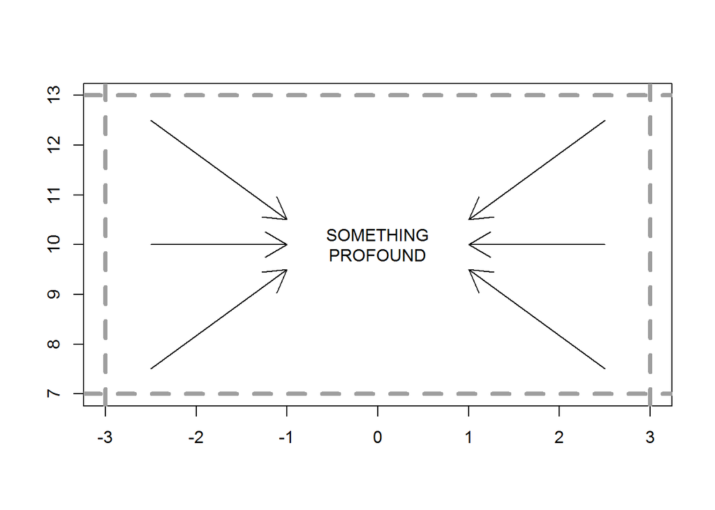

```r
#(a)
plot(-3:3,7:13,type="n",xlab="",ylab="")
text(x=0,y=10,labels="SOMETHING\nPROFOUND")
abline(v=c(-3,3),lty=2,lwd=4,col=8)
abline(h=c(7,13),lty=2,lwd=4,col=8)
arrows(x0=c(-2.5,-2.5,-2.5,2.5,2.5,2.5),y0=c(7.5,10,12.5,7.5,10,12.5),x1=c(-1,-1,-1,1,1,1),y1=c(9.5,10,10.5,9.5,10,10.5))
```

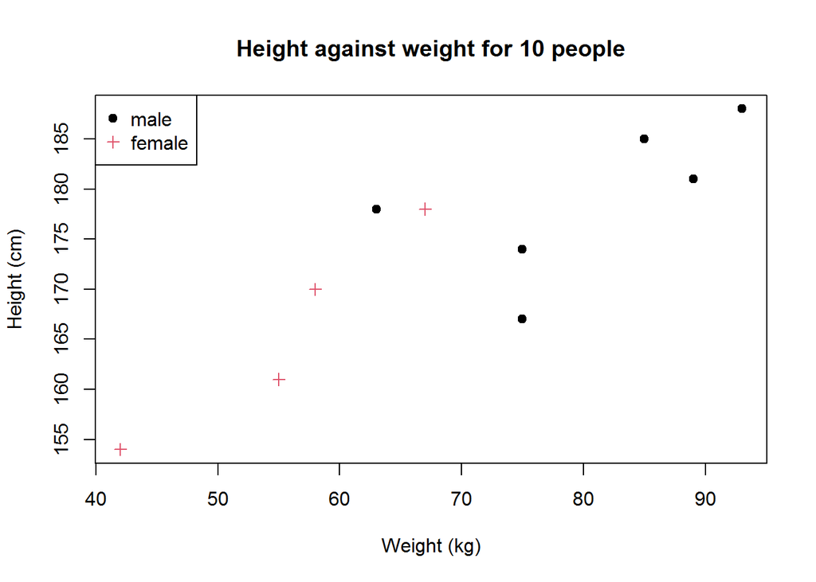

```r
#(b)
w <- c(55,85,75,42,93,63,58,75,89,67)
h <- c(161,185,174,154,188,178,170,167,181,178)
s <- c("female","male","male","female","male","male","female","male","male","female")
plot(w,h,type="n",xlab="Weight (kg)",ylab="Height (cm)",main="Height against weight for 10 people")
points(w[s=="male"],h[s=="male"],pch=19)
points(w[s=="female"],h[s=="female"],pch=3,col=2)
legend("topleft",legend=c("male","female"),pch=c(19,3),col=c(1,2))
```

Exercise 7.2

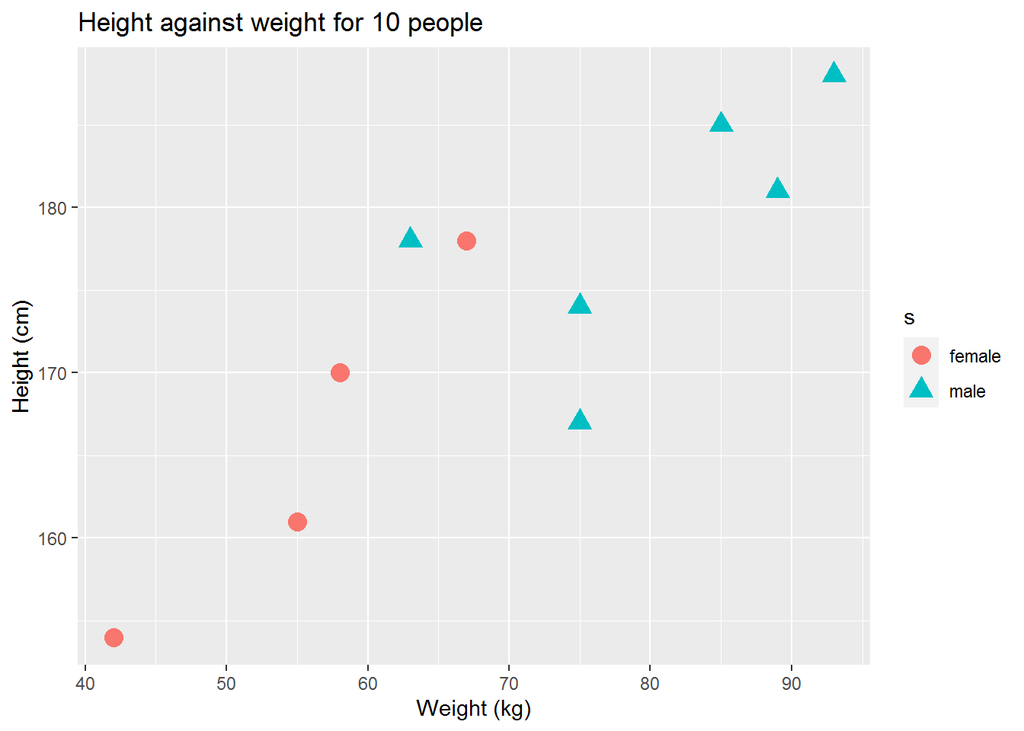

```r
library(ggplot2)
w <- c(55,85,75,42,93,63,58,75,89,67)
h <- c(161,185,174,154,188,178,170,167,181,178)
s <- factor(c("female","male","male","female","male","male","female","male","male","female"))
qplot(w,h,color=s,shape=s,xlab="Weight (kg)",ylab="Height (cm)",main="Height against weight for 10 people") + geom_point(size=4)
```

Exercise 8.1

```r
#(a)
##(i)
write.table(x=quakes[quakes$mag>=5,],file="q5.txt",row.names=F)
##(ii)
q5.dframe <- read.table(file="q5.txt",header=T)
#(b)
#install.packages("car")
library("car")
```

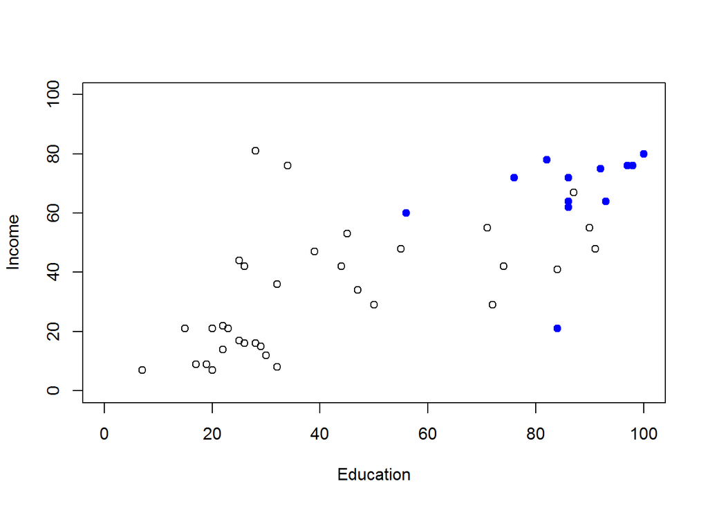

```r
data(Duncan)
##(i)
plot(Duncan$education[Duncan$prestige<=80],Duncan$income[Duncan$prestige<=80],xlim=c(0,100),ylim=c(0,100),xlab="Education",ylab="Income")
points(Duncan$education[Duncan$prestige>80],Duncan$income[Duncan$prestige>80],pch=19,col="blue")
```

```r
##(ii)
png("dunc.png",width=500,height=500)
plot(Duncan$education[Duncan$prestige<=80],Duncan$income[Duncan$prestige<=80],xlim=c(0,100),ylim=c(0,100),xlab="Education",ylab="Income")
points(Duncan$education[Duncan$prestige>80],Duncan$income[Duncan$prestige>80],pch=19,col="blue")
legend("topleft",legend=c("prestige > 80","prestige <= 80"),pch=c(19,1),col=c("blue","black"))
dev.off()
```

```r
#(c)
exer <- list(quakes,q5.dframe,Duncan)
##(i)
dput(x=exer,file="Exercise8-1Data.txt")
##(ii)
list.of.dataframes <- dget("Exercise8-1Data.txt")
head(list.of.dataframes,5)
```

[output not shown]

[output cut: 1236 more lines]

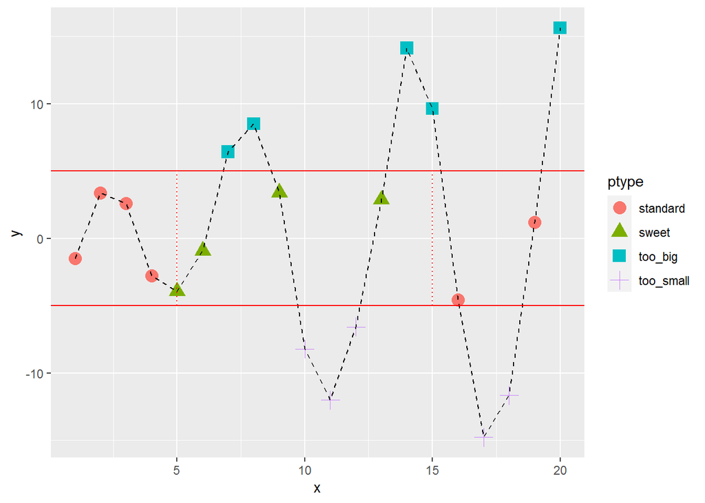

```r
#(d)
x <- 1:20
y <- c(-1.49,3.37,2.59,-2.78,-3.94,-0.92,6.43,8.51,3.41,-8.23,-12.01,-6.58,2.87,14.12,9.63,-4.58,-14.78,-11.67,1.17,15.62)
ptype <- rep(NA,length(x=x))
ptype[y>=5] <- "too_big"
ptype[y<=-5] <- "too_small"
ptype[(x>=5&x<=15)&(y>-5&y<5)] <- "sweet"
ptype[(x<5|x>15)&(y>-5&y<5)] <- "standard"
ptype <- factor(x=ptype)
qplot(x,y,color=ptype,shape=ptype) + geom_point(size=4) + geom_line(mapping=aes(group=1),color="black",lty=2) + geom_hline(mapping=aes(yintercept=c(-5,5)),color="red") + geom_segment(mapping=aes(x=5,y=-5,xend=5,yend=5),color="red",lty=3) + geom_segment(mapping=aes(x=15,y=-5,xend=15,yend=5),color="red",lty=3)
```

```r
ggsave(filename="elaborateqplot.tiff")
```